## Liquor Sales in Iowa

This dataset https://data.iowa.gov/Sales-Distribution/2019-Iowa-Liquor-Sales/38x4-vs5h contains the spirits purchase information of Iowa Class “E” liquor licensees by product and date of purchase for 2019. The dataset can be used to analyze total spirits sales in Iowa of individual products at the store level.

**Submission instructions**: Create a folder named `ds202_hw5`, and name the RMarkDown file including your solutions `hw5.Rmd` under this folder. For the submission, create a GitHub repository named `ds202_hw5` under your GitHub account, and push both `hw5.Rmd` and the knitted `hw5.html` before the deadline. I will assume you use the same GitHub username as for your HW4 submission. The latest version of your homework appearing on GitHub before the deadline is graded. *It is crucial to follow the exact folder structure and file names*, so that your homework can be reproduced and graded by an automated script. This homework is **due on April 10** by 11:59 pm.

## 1. The complete dataset is too large. Download and import the alcohol sales data for Ames only:

1. Go to https://data.iowa.gov/Sales-Distribution/2019-Iowa-Liquor-Sales/38x4-vs5h
2. Click Filter – Filter – Go advanced now
3. Add a New Filter Condition: City is Ames.
4. Export – CSV – Download
5. Use `readr::read_csv` to import.

```r
library(dplyr)
library(tidyverse)
```

```r
library(ggplot2)
library(lubridate)
liquor <- readr::read_csv("2019_Iowa_Liquor_Sales.csv")
```

## 2. Data cleaning:

### a. extract geographic latitude and longitude from the variable `Store Location`

```r
liquor$'Store Location' <- substring(liquor$'Store Location', 8, 26)
cleanLiquor <- liquor %>% separate('Store Location', c("Latitude", "Longitude"), sep = " ")
```

### b. make sure the variables are in the correct type, by converting incorrect variable types.

```r
cleanLiquor$Date <- mdy(cleanLiquor$Date)
cleanLiquor$Longitude <- as.numeric(cleanLiquor$Longitude)
cleanLiquor$Latitude <- as.numeric(cleanLiquor$Latitude)
cleanLiquor$'Vendor Number'<- as.numeric(cleanLiquor$'Vendor Number')
```

### c. extract year, month and day from the variable `Date` as separate columns.

```r
cleanLiquor <- cleanLiquor%>% separate(Date, c("Year", "Day", "Month"))
```

## 3. First overview:

### a.Plot a scatterplot of lat and long of store locations.

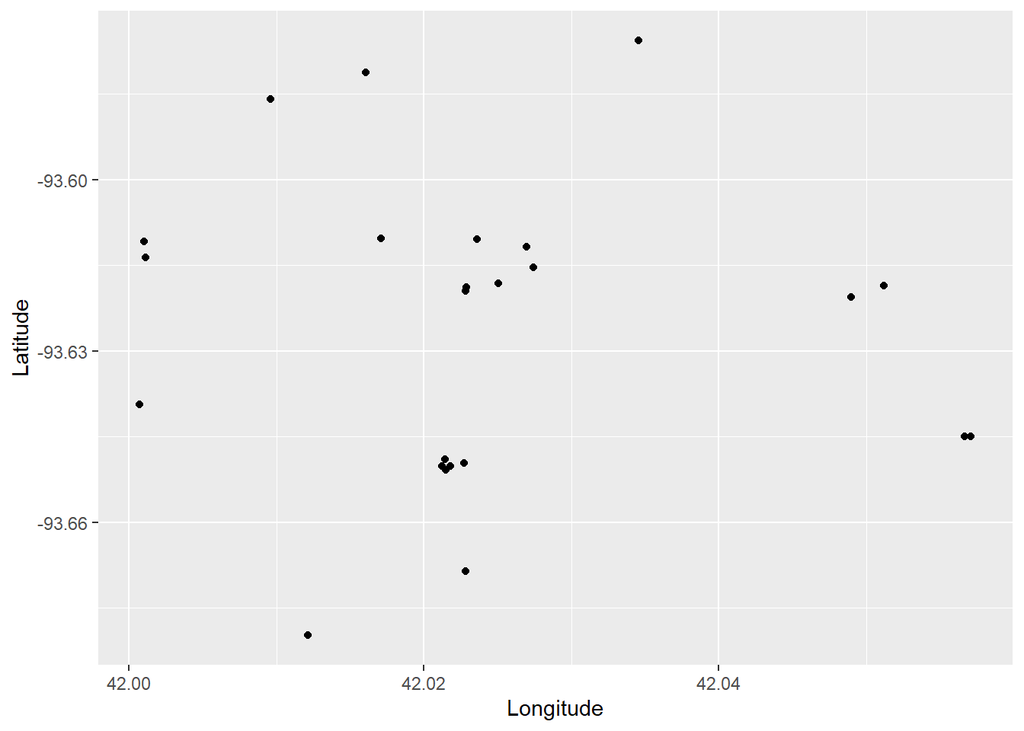

```r
cleanLiquor%>% ggplot(aes(x=Longitude, y=Latitude))+ geom_point(na.rm = TRUE)
```

### b.Provide a visual breakdown of the liquor category (by `Category Name`). Include volume sold in the breakdown.

```r
cleanLiquor%>% group_by(`Category Name`)%>% summarize('Liters Sold' = sum(`Volume Sold (Liters)`), 'Gallons Sold' = sum(`Volume Sold (Gallons)`))
```

```
## # A tibble: 52 x 3
##    `Category Name`                      `Liters Sold` `Gallons Sold`
##    <chr>                                        <dbl>          <dbl>
##  1 100% Agave Tequila                           9128.        2398.
##  2 Aged Dark Rum                                1184          311.
##  3 American Brandies                            6833.        1797.
##  4 American Cordials & Liqueur                  4965.        1304.
##  5 American Distilled Spirit Specialty           305.          80.0
##  6 American Distilled Spirits Specialty            9            2.36
##  7 American Dry Gins                           12233.        3224.
##  8 American Flavored Vodka                     31087.        8187.
##  9 American Schnapps                           11353         2991.
## 10 American Sloe Gins                             42           11.1
## # ... with 42 more rows
```

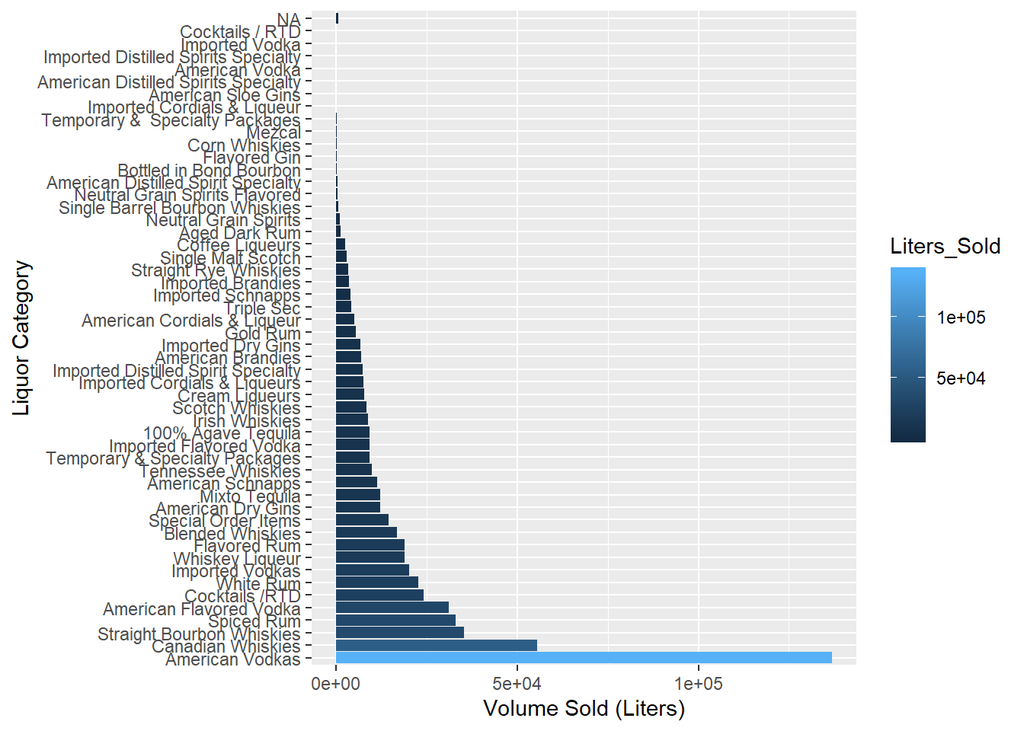

```r
cleanLiquor %>% group_by(`Category Name`) %>% summarize(Liters_Sold = sum(`Volume Sold (Liters)`)) %>% select(`Category Name`, Liters_Sold) %>% ggplot(aes(x=reorder(`Category Name`, -Liters_Sold), y=Liters_Sold, fill=Liters_Sold)) + geom_bar(stat="identity") + coord_flip() + xlab('Liquor Category') + ylab('Volume Sold (Liters)')
```

As seen above, American Vodkas is the alcohol with the mist sales by a lot.This is probably due to the cost and availability of this type of product. Moreover, I did not expect that Canadian Whiskey would be the second most sold alcohol.

There is also a table provided to compare exact gallon and liter amounts with sales of each of the alcohol products.

## 4. Find the daily sales liquor sales in Ames in 2019. Summarize the number of sales, volume of liquor sold, and amount of money spent.

```r
sales <- cleanLiquor%>% group_by(Year, Month, Day) %>% summarise("Num. Sold" = n(), "Volume Sold (Gallons)"= sum(`Volume Sold (Gallons)`), "Volume Sold (Liters)" = sum(`Volume Sold (Liters)`), "Money Spent" = sum(`Sale (Dollars)`))
sales
```

```
## # A tibble: 157 x 7
## # Groups:   Year, Month [31]
##    Year  Month Day   `Num. Sold` `Volume Sold (G~ `Volume Sold (L~ `Money Spent`
##    <chr> <chr> <chr>       <int>            <dbl>            <dbl>         <dbl>
##  1 2019  01    02            137           333.              1263.       19438.
##  2 2019  01    03            179           410.              1557.       22531.
##  3 2019  01    05            118           558.              2115.       31963.
##  4 2019  01    08            552           717.              2728.       44361.
##  5 2019  01    10             26            49.0              186         3526.
##  6 2019  01    11             44           172.               652.        6512.
##  7 2019  02    05           1173          2261.              8585.      132643.
##  8 2019  02    07              1             0.26               1           18.8
##  9 2019  02    08             57            65.6              249.        4046.
## 10 2019  02    10            441          1131.              4288.       65284.
## # ... with 147 more rows
```

## 5. Plot volume sold by day (use a scatterplot of volume by day and facet by month). Discover trends with the help of `geom_smooth`. Describe any patterns.

[figure not shown]

```r
sales%>% ggplot(aes(x=Day, y='Volume Sold (Liters)'))+ geom_point(position = 'jitter')+geom_smooth(se= FALSE)+facet_wrap(~Month)+ ggtitle("Alchohol sold in Ames in 2019 by volume and month")
```

## 6. Find the dates for ISU football home games in Fall 2019. Can you see a pattern?

The Iowa State home games in 2019 were as follows: 8/31/19, 9/14/19, 9/21/19, 10/5/19, 10/26/19, 11/16/19, 11/23/19.

Note: your submission is supposed to be fully reproducible, i.e. the TA and I will ‘knit’ your submission in RStudio.